## Assignment #1: Data Exploration

#### Last Updated: 9/18/26

## Description

The Coral Reef Evaluation and Monitoring Project (CREMP) was designed to document the health status of selected coral reefs along Florida’s Coral Reef. The project conducts annual surveys along permanent transects at each site to collect coral and octocoral population demographics, health conditions, and benthic community assemblage cover.

This project will focus specifically on the octocoral population demographics data collected between 2012-2025. These surveys collect conditions data for five target species as well as a tally of all octocoral colonies with erect morphology.

- **Link to CREMP overview:** https://myfwc.com/research/habitat/coral/cremp/

**Database citations:**

- FWC Coral Research Program. (2022). Florida Keys Coral Reef Evaluation Monitoring Project CSV Files Download [data files]. Florida Fish and Wildlife Conservation Commission-Fish and Wildlife Research Institute [producer]. <[https://geodata.myfwc.com\\](https://geodata.myfwc.com){.uri}>
- FWC Coral Research Program. (2022). Dry Tortugas Coral Reef Evaluation Monitoring Project CSV Files Download [data files]. Florida Fish and Wildlife Conservation Commission-Fish and Wildlife Research Institute [producer]. <[https://geodata.myfwc.com\\](https://geodata.myfwc.com){.uri}>

## Data Structure

```r
# Read in dataset
octo_tally_master <- read.csv("https://raw.githubusercontent.com/caroline-link/Biometry/refs/heads/main/CREMP_OCTO_Data/CREMP_OCTO_Tallies_Masterfile.csv")

octo_conditions_master <- read.csv("https://raw.githubusercontent.com/caroline-link/Biometry/refs/heads/main/CREMP_OCTO_Data/CREMP_OCTO_Condition_Masterfile.csv")
```

```r
# Determine octocoral tallies dataset class and variables of interest
class(octo_tally_master)
```

```
## [1] "data.frame"
```

```r
str(octo_tally_master)
```

```
## 'data.frame':    1800 obs. of  14 variables:
##  $ SampleYear     : int  2011 2011 2011 2011 2011 2011 2011 2011 2011 2011 ...
##  $ FirstSampleDate: chr  "2011-06-29" "2011-06-29" "2011-06-29" "2011-06-29" ...
##  $ ProjectRegion  : chr  "NPSDT" "NPSDT" "NPSDT" "NPSDT" ...
##  $ Subregion      : chr  "DT" "DT" "DT" "DT" ...
##  $ Habitat        : chr  "P" "P" "P" "P" ...
##  $ SiteCode       : chr  "1PA" "1PA" "1PA" "1PA" ...
##  $ SiteID         : int  27 27 27 27 28 28 28 28 29 29 ...
##  $ SiteName       : chr  "The Maze" "The Maze" "The Maze" "The Maze" ...
##  $ StationID      : int  271 272 273 274 281 282 283 284 291 292 ...
##  $ TRANSECT       : chr  "300-10" "300-10" "300-10" "300-10" ...
##  $ AbbrName       : chr  "OCTO" "OCTO" "OCTO" "OCTO" ...
##  $ SciName        : chr  "Total Octocoral" "Total Octocoral" "Total Octocoral" "Total Octocoral" ...
##  $ Tally          : int  78 58 54 55 0 0 0 0 7 8 ...
##  $ Density        : num  7.8 5.8 5.4 5.5 0 0 0 0 0.7 0.8 ...
```

- The colony tally dataset is a **data frame**, made up of 1,800 observations of 14 variables.
- **Variables of interest include:** SampleYear (integer), Subregion (character), Habitat (character), SiteID (integer), Tally (integer), and Density (numeric)

```r
# Determine octocoral conditions dataset class and variables of interest
class(octo_conditions_master)
```

```
## [1] "data.frame"
```

```r
str(octo_conditions_master)
```

```
## 'data.frame':    150118 obs. of  40 variables:
##  $ SampleYear   : int  2011 2011 2011 2011 2011 2011 2011 2011 2011 2011 ...
##  $ Date         : chr  "2011-06-29" "2011-06-29" "2011-06-29" "2011-06-29" ...
##  $ ProjectRegion: chr  "NPSDT" "NPSDT" "NPSDT" "NPSDT" ...
##  $ RECORDER     : chr  "vbrinkhuis" "vbrinkhuis" "vbrinkhuis" "vbrinkhuis" ...
##  $ subRegionId  : chr  "DT" "DT" "DT" "DT" ...
##  $ habitatid    : chr  "P" "P" "P" "P" ...
##  $ Site.Code    : chr  "1PA" "1PA" "1PA" "1PA" ...
##  $ siteid       : int  27 27 27 27 27 27 27 27 27 27 ...
##  $ sitename     : chr  "The Maze" "The Maze" "The Maze" "The Maze" ...
##  $ StationID    : int  271 271 271 271 271 271 271 271 271 271 ...
##  $ TRANSECT     : chr  "300-10" "300-10" "300-10" "300-10" ...
##  $ SPP_Code     : chr  "PAME" "PFLE" "GVEN" "PFLE" ...
##  $ Height.cm.   : int  34 14 4 35 25 30 10 41 12 8 ...
##  $ Condition    : chr  "OGI;" NA NA NA ...
```

[output cut: 26 more lines]

- The conditions dataset is a **data frame**, consisting of 150,118 observations of 40 variables.
- **Variables of interest include**: SampleYear (integer), subRegionId (character), habitatid (character), siteid (integer), SPP_Code (character), and Height.cm (integer).

## Data Cleaning

```r
# Check first and last sample year
range(octo_tally_master$SampleYear)
```

```
## [1] 2011 2025
```

```r
range(octo_conditions_master$SampleYear)
```

```
## [1] 2011 2025
```

```r
# Subset to 2012-2025
tally <- filter(octo_tally_master, SampleYear>2011)
conditions <- filter(octo_conditions_master, SampleYear>2011)


# Check that both datasets have the same number of sites
n_distinct(tally$SiteID)
```

```
## [1] 32
```

```r
n_distinct(conditions$siteid)
```

```
## [1] 32
```

```r
# Check that tally dataset has an equal or greater number of sites per year
tally |>
  group_by(SampleYear) |>
  summarise(n_sites_tally = n_distinct(SiteID))
```

```
## # A tibble: 14 × 2
##    SampleYear n_sites_tally
##         <int>         <int>
##  1       2012            29
##  2       2013            29
##  3       2014            31
##  4       2015            32
##  5       2016            32
##  6       2017            32
##  7       2018            31
##  8       2019            31
##  9       2020            31
## 10       2021            31
## 11       2022            31
## 12       2023            31
## 13       2024            31
## 14       2025            31
```

```r
conditions |>
  group_by(SampleYear) |>
  summarise(n_sites_conditions = n_distinct(siteid))
```

```
## # A tibble: 14 × 2
##    SampleYear n_sites_conditions
##         <int>              <int>
##  1       2012                 28
##  2       2013                 28
##  3       2014                 30
##  4       2015                 31
##  5       2016                 31
##  6       2017                 31
##  7       2018                 30
##  8       2019                 30
##  9       2020                 30
## 10       2021                 30
## 11       2022                 30
## 12       2023                 31
## 13       2024                 29
## 14       2025                 29
```

```r
# Check for any NAs
anyNA(tally)
```

```
## [1] FALSE
```

```r
anyNA(conditions)
```

```
## [1] TRUE
```

```r
# Pull rows with NAs to see if they're appropriate
conditions_w_NA <- conditions[!complete.cases(conditions), ]

head(conditions_w_NA)
```

```
##   SampleYear       Date ProjectRegion RECORDER subRegionId habitatid Site.Code
## 1       2012 2012-06-01         NPSDT rruzicka          DT         P       1PA
## 2       2012 2012-06-01         NPSDT rruzicka          DT         P       1PA
## 3       2012 2012-06-01         NPSDT rruzicka          DT         P       1PA
## 4       2012 2012-06-01         NPSDT rruzicka          DT         P       1PA
## 5       2012 2012-06-01         NPSDT rruzicka          DT         P       1PA
## 6       2012 2012-06-01         NPSDT rruzicka          DT         P       1PA
##   siteid sitename StationID TRANSECT SPP_Code Height.cm. Condition BLH PBL PAL
## 1     27 The Maze       271   300-10     PFLE          5      <NA>   0   0   0
## 2     27 The Maze       271   300-10     PAME         45      <NA>   0   0   0
## 3     27 The Maze       271   300-10     GVEN          6      <NA>   0   0   0
## 4     27 The Maze       271   300-10     PFLE         20      <NA>   0   0   0
## 5     27 The Maze       271   300-10     PFLE         35      <NA>   0   0   0
## 6     27 The Maze       271   300-10     PAME         25      <NA>   0   0   0
##   CYP HRM TRI PRD RBD ASP PSD BLK BWD UNK AGL TSL ABR DMG OGH OGC OGI OGB OGM
## 1   0   0   0   0   0   0   0   0   0   0   0   0   0   0   0   0   0   0   0
## 2   0   0   0   0   0   0   0   0   0   0   0   0   0   0   0   0   0   0   0
## 3   0   0   0   0   0   0   0   0   0   0   0   0   0   0   0   0   0   0   0
## 4   0   0   0   0   0   0   0   0   0   0   0   0   0   0   0   0   0   0   0
## 5   0   0   0   0   0   0   0   0   0   0   0   0   0   0   0   0   0   0   0
## 6   0   0   0   0   0   0   0   0   0   0   0   0   0   0   0   0   0   0   0
##   OGS OGT OGA OGO
## 1   0   0   0   0
## 2   0   0   0   0
## 3   0   0   0   0
## 4   0   0   0   0
## 5   0   0   0   0
## 6   0   0   0   0
```

```r
# Check target species in conditions dataset
unique(conditions$SPP_Code)
```

```
##  [1] "PFLE"      "PAME"      "GVEN"      "PBIP"      "PPOR"      "ECAL"
##  [7] "PKAL"      "PKUN"      "PBIP/PKAL" "UNKO"      "PACE"      "ETOU"
## [13] "ANTI"      "ANTI/GVEN" "NS-PAME"
```

```r
# Check number of colonies IDed to Antillogorgia (genus) but not species
## NOTE: may want to re-evaluate in the future
conditions |>
  filter(SPP_Code %in% c("ANTI",
                         "ANTI/GVEN"))
```

```
##    SampleYear       Date ProjectRegion  RECORDER subRegionId habitatid
## 1        2017 2017-07-16         FKNMS kcummings          UK        OS
## 2        2017 2017-07-16         FKNMS kcummings          UK        OS
## 3        2017 2017-07-16         FKNMS kcummings          UK        OS
## 4        2017 2017-07-16         FKNMS kcummings          UK        OS
## 5        2017 2017-07-16         FKNMS kcummings          UK        OS
## 6        2017 2017-07-16         FKNMS kcummings          UK        OS
## 7        2017 2017-07-16         FKNMS kcummings          UK        OS
## 8        2017 2017-07-16         FKNMS kcummings          UK        OS
## 9        2017 2017-07-16         FKNMS kcummings          UK        OS
## 10       2017 2017-07-16         FKNMS kcummings          UK        OS
## 11       2017 2017-07-16         FKNMS kcummings          UK        OS
## 12       2017 2017-07-16         FKNMS kcummings          UK        OS
## 13       2017 2017-07-16         FKNMS kcummings          UK        OS
## 14       2017 2017-07-16         FKNMS kcummings          UK        OS
```

[output cut: 93 more lines]

```r
# Limit to five current target species, recode NS-PAME as PAME
conditions_targets <- conditions |>
                      mutate (SPP_Code = recode(
                                            SPP_Code,
                                            "NS-PAME" = "PAME")) |>
                      filter(SPP_Code %in% c("PFLE",
                                             "PAME",
                                             "GVEN",
                                             "PBIP",
                                             "PPOR"))


# Check counts of PAME and NS-PAME vs. combined count
conditions|>
  filter(SPP_Code %in% c("PAME",
                         "NS-PAME")) |>
  nrow()
```

```
## [1] 59570
```

```r
conditions_targets|>
  filter(SPP_Code == "PAME") |>
  nrow()
```

```
## [1] 59570
```

## Summary Statistics

```r
# Find number of sites in each region
conditions_targets |>
  group_by(subRegionId) |>
  summarise(sites_per_region = n_distinct(siteid))
```

```
## # A tibble: 4 × 2
##   subRegionId sites_per_region
##   <chr>                  <int>
## 1 DT                        11
## 2 LK                         7
## 3 MK                         8
## 4 UK                         6
```

```r
# Find number of sites per habitat type in each region
conditions_targets |>
  group_by(subRegionId, habitatid) |>
  summarize(n_sites = n_distinct(siteid)) |>
  pivot_wider(names_from = subRegionId,
  values_from = n_sites)
```

```
## `summarise()` has regrouped the output.
## ℹ Summaries were computed grouped by subRegionId and habitatid.
## ℹ Output is grouped by subRegionId.
## ℹ Use `summarise(.groups = "drop_last")` to silence this message.
## ℹ Use `summarise(.by = c(subRegionId, habitatid))` for per-operation grouping
##   (`?dplyr::dplyr_by`) instead.
```

```
## # A tibble: 3 × 5
##   habitatid    DT    LK    MK    UK
##   <chr>     <int> <int> <int> <int>
## 1 OD            2     2     3     2
## 2 P             9     3     2     2
## 3 OS           NA     2     3     2
```

```r
# Compare octocoral densities from tally dataset
summary(tally$Density)
```

```
##    Min. 1st Qu.  Median    Mean 3rd Qu.    Max.
##    0.00    4.80   10.15   12.75   17.50   67.00
```

```r
# Find mean octocoral density per site
tally |>
  group_by(SiteID) |>
  summarise(average_annual_tally = mean(Density))
```

```
## # A tibble: 32 × 2
##    SiteID average_annual_tally
##     <int>                <dbl>
##  1     26              13.7
##  2     27               5.76
##  3     28               0.0161
##  4     29               0.646
##  5     32              13.4
##  6     33              24.8
##  7     34              11.4
##  8     35              13.1
##  9     36               5.11
## 10     38               8.24
## # ℹ 22 more rows
```

```r
# Find summary of target species height
conditions_targets |>
  group_by(SPP_Code) |>
  summarise(min_height = min(Height.cm.),
            max_height = max(Height.cm.),
            avg_height = mean(Height.cm.),
            sd = sd(Height.cm.))
```

```
## # A tibble: 5 × 5
##   SPP_Code min_height max_height avg_height    sd
##   <chr>         <int>      <int>      <dbl> <dbl>
## 1 GVEN              1        145       17.4  17.7
## 2 PAME              1        162       21.5  17.4
## 3 PBIP              1        139       17.5  13.7
## 4 PFLE              1        115       24.9  19.6
## 5 PPOR              1        165       33.2  32.0
```

## Figures

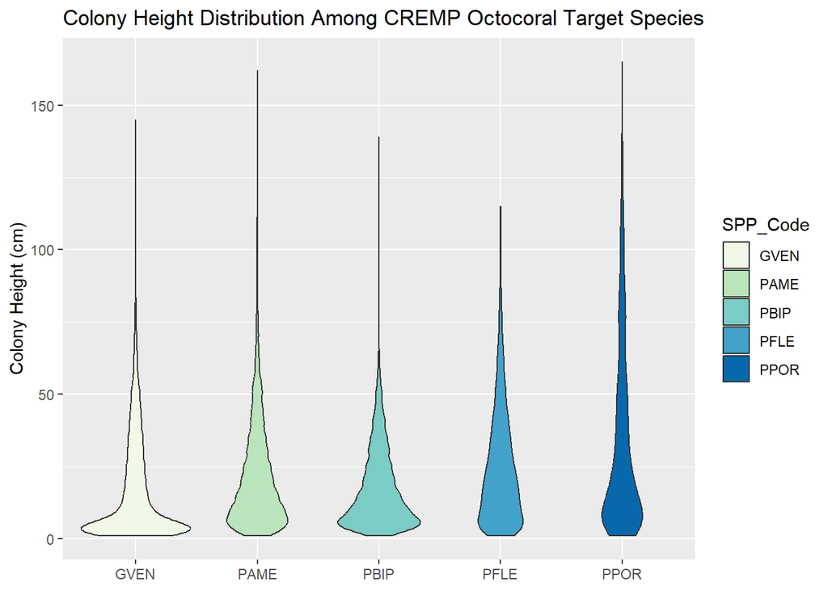

```r
# Figure 1: Boxplot comparing colony height
conditions_targets |>
  group_by(SPP_Code) |>
  ggplot(mapping = aes(x = SPP_Code,
                       y = Height.cm.,
                       fill = SPP_Code)) +
  geom_violin() +
  labs(title = "Colony Height Distribution Among CREMP Octocoral Target Species",
       y = "Colony Height (cm)" ) +
  theme(axis.title.x = element_blank()) +
  scale_fill_brewer(palette = "GnBu")
```

- **Figure 1:** Distribution of colony height (cm) measurements recorded for the five CREMP target octocoral species from 2012-2025. Height distributions vary slightly between target species, but are generally skewed right with a majority of colonies falling under 50 cm.

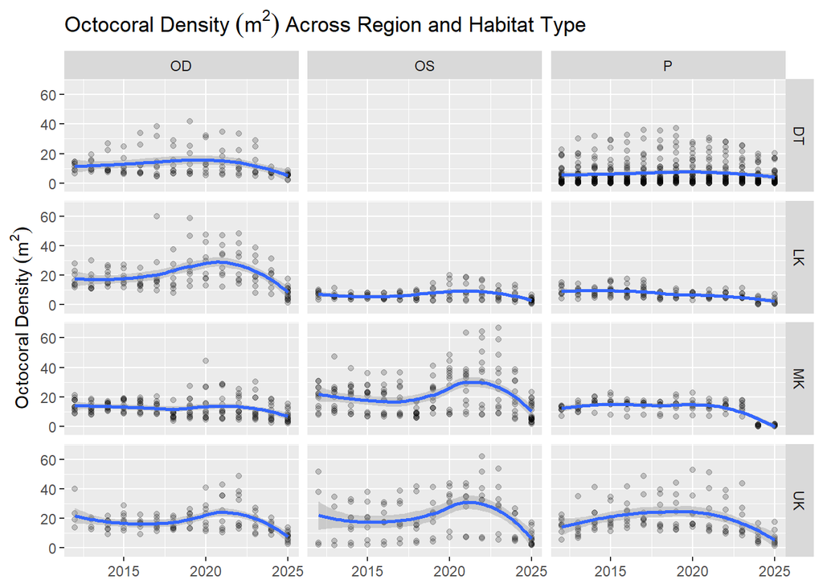

```r
# Figure 2: Scatterplot of total octocoral density across region and habitat
tally |>
  group_by(Subregion, SampleYear, Habitat) |>
  ggplot(tally, mapping = aes(x = SampleYear,
                              y = Density)) +
  geom_point(alpha = 0.2) +
  geom_smooth() +
  facet_grid(Subregion ~ Habitat) +
  labs(title = bquote("Octocoral Density" ~(m^2)~"Across Region and Habitat Type"),
       y = bquote("Octocoral Density" ~(m^2))) +
  theme(axis.title.x = element_blank())
```

- **Figure 2:** Total octocoral colony density (m<sup>2</sup>), including target and non-target species, recorded per site from 2012-2025. Plots are divided by region and habitat type, the OS X DT plot is empty because there are no offshore patch reefs in the Dry Tortugas. Colony densities have gradually declined across regions and habitat types, and declines were not offset by an apparent recruitment boom between 2020-2022.

```
## `summarise()` has regrouped the output.
## ℹ Summaries were computed grouped by SPP_Code and SampleYear.
## ℹ Output is grouped by SPP_Code.
## ℹ Use `summarise(.groups = "drop_last")` to silence this message.
## ℹ Use `summarise(.by = c(SPP_Code, SampleYear))` for per-operation grouping
##   (`?dplyr::dplyr_by`) instead.
```

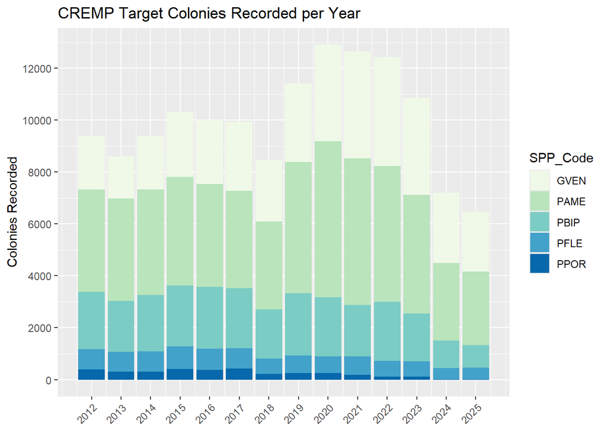

```r
# Figure 3: barplot of number of target colonies per year
conditions_targets |>
  group_by(SPP_Code, SampleYear) |>
  summarise(total_colonies = n()) |>
  ggplot(mapping = aes(x = SampleYear,
                       y = total_colonies,
                       fill = SPP_Code)) +
  geom_bar(stat = "identity") +
  labs(title = "CREMP Target Colonies Recorded per Year",
       y = "Colonies Recorded" ) +
  scale_x_continuous(breaks = seq(2012, 2025, seq=1)) +
  theme(axis.text.x = element_text(angle=45, hjust = 1)) +
  scale_y_continuous(n.breaks = 10) +
  scale_fill_brewer(palette = "GnBu") +
  theme(axis.title.x = element_blank())
```